# Assignment 6

- Implement the (adapted) TriNet Siamese model and SimCLR:
  - ResNet convolutional backbone (until AvgPool)
  - Fully connected frontend to obtain desired embedding
  - Normalization layer
- Use *Labeled Faces in the Wild* (LFW) dataset (https://www.kaggle.com/datasets/jessicali9530/lfw-dataset)
  - Over 13000 images
  - Train and test set
- Train and Evaluate TriNet and SimCLR models
  - Try to find adequate temperature and margin values
  - How do the models compare?
- Evaluate and compare the model performance (need not be thorough)
- Visualize embeddings (not necessary for all classes, e.g. pick the 10 classes with the most images)
- **Extra Point**:
  - Take one or a few images/selfies from the members in your group. Try to use different iluminations, angles, ...
  - Does your model predict similar embeddings for your images?
  - How similar are you with your group partner?
  - To which celebrity does your model think you look like?

```python
from sklearn.datasets import fetch_lfw_people
from sklearn.metrics import confusion_matrix
from sklearn.model_selection import train_test_split
from torchvision import models, transforms
import torch.nn.functional as F
%matplotlib inline
import matplotlib.pyplot as plt
import torch
import random
import numpy as np
import torch.nn as nn
import utils
# from imblearn.over_sampling import RandomOverSampler
import importlib
importlib.reload(utils)
device = torch.device("cuda" if torch.cuda.is_available() else "cpu")
```

```python
%load_ext autoreload
%autoreload 2
```

```
The autoreload extension is already loaded. To reload it, use:
  %reload_ext autoreload
```

### Data visualization

[figure not shown]

```
Dataset shape: (2370, 71148)
Total images: 2370
Image dimensions: 71148 pixels
Total labels: 2370
Reshaped image size: 154x154x3 pixels (RGB)
Number of people/classes: 34
```

```python
## Load using torchvision
# train_dataset = datasets.LFWPeople(root='./data', split="train", transform=transform, download=True)
# test_dataset = datasets.LFWPeople(root='./data', split="test", transform=transform, download=True)

# train_loader = torch.utils.data.DataLoader(dataset=train_dataset, batch_size=64, shuffle=True)
# test_loader = torch.utils.data.DataLoader(dataset=test_dataset, batch_size=64, shuffle=False)

# We use the following slicing to get more meaningful cut of images
lfw_people = fetch_lfw_people(min_faces_per_person=30, color=True, resize=1.0,
                              slice_=(slice(48, 202), slice(48, 202)))

# Get the data and target
X = lfw_people.data
y = lfw_people.target
target_names = lfw_people.target_names
# print(target_names)

# Images are flattened, so we need to reshape them into 3 channels square images
total_pixels = X.shape[1] // 3
height = int(total_pixels ** 0.5)  # Assuming square images
width = total_pixels // height

# Finding one image per person
fig, axes = plt.subplots(5, 5, figsize=(12, 12))
axes = axes.ravel()
unique_labels = np.unique(y)[4:29]
num_people = len(unique_labels)

for i, label in enumerate(unique_labels):
    # Find the first image for this person
    person_indices = np.where(y == label)[0]
    first_image_idx = person_indices[0]

    # Reshape and display the image
    img = X[first_image_idx].reshape(height, width, 3)
    axes[i].imshow(img)
    axes[i].set_title(f'{target_names[label]}')
    axes[i].axis('off')

plt.tight_layout()
plt.show()

print(f"Dataset shape: {X.shape}")
print(f"Total images: {X.shape[0]}")
print(f"Image dimensions: {X.shape[1]} pixels")
print(f"Total labels: {len(y)}")
print(f"Reshaped image size: {height}x{width}x3 pixels (RGB)")
print(f"Number of people/classes: {len(target_names)}")
```

```python
lfw_people = fetch_lfw_people(min_faces_per_person=50, color=True, resize=1.0,
                              slice_=(slice(48, 202), slice(48, 202)))
# train/test split
X_train, X_test, y_train, y_test = train_test_split(X, y, test_size=0.2,
                                                    stratify=y, random_state=42)
# stratify ensures that each class is represented in the same proportion in both training and test sets.
```

```python
class TripletDataset:
    """
    Dataset class from which we sample random triplets
    """
    def __init__(self, dataset, labels, transform=None):
        """ Dataset initializer"""
        self.dataset = dataset
        self.labels = labels
        self.transform = transform

        # Calculate dimensions for reshaping
        total_pixels = dataset.shape[1] // 3
        self.height = int(total_pixels ** 0.5)  # Assuming square images
        self.width = total_pixels // self.height
        return

    def __len__(self):
        """ Returning number of anchors """
        return len(self.labels)

    def __getitem__(self, i):
        """
        Sampling a triplet for the dataset. Index i corresponds to anchor
        """
        # sampling anchor
        anchor_img = self.dataset[i].reshape(self.height, self.width, 3)  # Reshape to HxWx3
        anchor_lbl = self.labels[i]

        # lists for positives and negatives
        pos_ids = np.where(self.labels == anchor_lbl)[0]
        neg_id = np.where(self.labels != anchor_lbl)[0]

        # random positive and negative
        pos_id, neg_id = random.choice(pos_ids).item(), random.choice(neg_id).item()  # BIG FLAW HERE!
        pos_img, pos_lbl = self.dataset[pos_id].reshape(self.height, self.width, 3) , self.labels[pos_id]
        neg_img, neg_lbl = self.dataset[neg_id].reshape(self.height, self.width, 3) , self.labels[neg_id]

        if self.transform:
            anchor_img = self.transform(anchor_img)
            pos_img = self.transform(pos_img)
            neg_img = self.transform(neg_img)

        return (anchor_img, pos_img, neg_img), (anchor_lbl, pos_lbl, neg_lbl)
```

```python
transform = transforms.Compose([
    transforms.ToTensor(),
    transforms.Resize((64, 64)),
])

train_dataset = TripletDataset(X_train, y_train, transform)
test_dataset = TripletDataset(X_test, y_test, transform)

(anchor_img, pos_img, neg_img) , _ = train_dataset[0]
print(anchor_img.shape, pos_img.shape, neg_img.shape)
```

```
torch.Size([3, 64, 64]) torch.Size([3, 64, 64]) torch.Size([3, 64, 64])
```

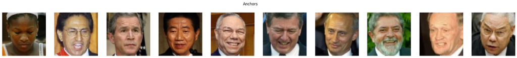

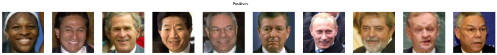

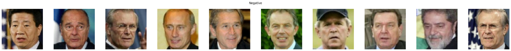

```python
fig_anchors, anchors = plt.subplots(1, 10, figsize=(30,3))
fig_pos, positives = plt.subplots(1, 10, figsize=(30,3))
fig_neg, negatives = plt.subplots(1, 10, figsize=(30,3))
for i in range(10):
    (anchor, positive, negative), _ = train_dataset[i]
    # Reverse the transform: convert tensor back to numpy and transpose
    anchor_np = anchor.permute(1, 2, 0).numpy()  # CHW -> HWC
    positive_np = positive.permute(1, 2, 0).numpy()
    negative_np = negative.permute(1, 2, 0).numpy()

    anchors[i].imshow(anchor_np)
    anchors[i].axis("off")
    positives[i].imshow(positive_np)
    positives[i].axis("off")
    negatives[i].imshow(negative_np)
    negatives[i].axis("off")
fig_anchors.suptitle("Anchors")
fig_pos.suptitle("Positives")
fig_neg.suptitle("Negative")
plt.tight_layout()
plt.show()
```

```python
train_loader = torch.utils.data.DataLoader(dataset=train_dataset, batch_size=64, shuffle=True)
test_loader = torch.utils.data.DataLoader(dataset=test_dataset, batch_size=64, shuffle=False)
```

```python
class SiameseModel(nn.Module):
    """
    Implementation of a simple siamese model
    """
    def __init__(self, emb_dim=64):
        """ Module initializer """
        super().__init__()

        # initialize resnet as backbone for feature extraction
        self.resnet = models.resnet18(weights=None)
        self.resnet.conv1 = nn.Conv2d(3, 64, kernel_size=7, stride=2, padding=3, bias=False)
        self.resnet.fc = nn.Identity()

        # projection head
        self.proj_head = nn.Sequential(
                nn.Linear(512, emb_dim),
                nn.ReLU(),
                nn.Linear(emb_dim, emb_dim)
            )
        self.cnn = self.resnet
        # auxiliar layers
        # self.flatten = nn.Flatten()
        self.norm = utils.NormLayer()

        return

    def forward_one(self, x):
        """ Forwarding just one sample through the model """
        x_emb = self.proj_head(self.cnn(x))
        x_emb_norm = self.norm(x_emb)
        return x_emb_norm

    def forward(self, anchor, positive, negative):
        """ Forwarding a triplet """
        # anchor_emb = self.forward_one(anchor)
        # positive_emb = self.forward_one(positive)
        # negative_emb = self.forward_one(negative)

        # is there a more efficient way? anchor (B, C, H, W)
        all_inputs = torch.cat([anchor, positive, negative], dim=0)  # (3 * B, C, H, W)
        all_embs = self.forward_one(all_inputs)
        anchor_emb, positive_emb, negative_emb = all_embs.chunk(3, dim=0)

        return anchor_emb, positive_emb, negative_emb
```

```python
model = SiameseModel()
```

```python
print(f"Model has {utils.count_model_params(model)} parameters")
model
```

```
Model has 11213504 parameters
```

```
SiameseModel(
  (resnet): ResNet(
    (conv1): Conv2d(3, 64, kernel_size=(7, 7), stride=(2, 2), padding=(3, 3), bias=False)
    (bn1): BatchNorm2d(64, eps=1e-05, momentum=0.1, affine=True, track_running_stats=True)
    (relu): ReLU(inplace=True)
    (maxpool): MaxPool2d(kernel_size=3, stride=2, padding=1, dilation=1, ceil_mode=False)
    (layer1): Sequential(
      (0): BasicBlock(
        (conv1): Conv2d(64, 64, kernel_size=(3, 3), stride=(1, 1), padding=(1, 1), bias=False)
        (bn1): BatchNorm2d(64, eps=1e-05, momentum=0.1, affine=True, track_running_stats=True)
        (relu): ReLU(inplace=True)
        (conv2): Conv2d(64, 64, kernel_size=(3, 3), stride=(1, 1), padding=(1, 1), bias=False)
        (bn2): BatchNorm2d(64, eps=1e-05, momentum=0.1, affine=True, track_running_stats=True)
      )
      (1): BasicBlock(
        (conv1): Conv2d(64, 64, kernel_size=(3, 3), stride=(1, 1), padding=(1, 1), bias=False)
        (bn1): BatchNorm2d(64, eps=1e-05, momentum=0.1, affine=True, track_running_stats=True)
        (relu): ReLU(inplace=True)
        (conv2): Conv2d(64, 64, kernel_size=(3, 3), stride=(1, 1), padding=(1, 1), bias=False)
        (bn2): BatchNorm2d(64, eps=1e-05, momentum=0.1, affine=True, track_running_stats=True)
      )
    )
    (layer2): Sequential(
      (0): BasicBlock(
        (conv1): Conv2d(64, 128, kernel_size=(3, 3), stride=(2, 2), padding=(1, 1), bias=False)
        (bn1): BatchNorm2d(128, eps=1e-05, momentum=0.1, affine=True, track_running_stats=True)
        (relu): ReLU(inplace=True)
        (conv2): Conv2d(128, 128, kernel_size=(3, 3), stride=(1, 1), padding=(1, 1), bias=False)
        (bn2): BatchNorm2d(128, eps=1e-05, momentum=0.1, affine=True, track_running_stats=True)
        (downsample): Sequential(
          (0): Conv2d(64, 128, kernel_size=(1, 1), stride=(2, 2), bias=False)
          (1): BatchNorm2d(128, eps=1e-05, momentum=0.1, affine=True, track_running_stats=True)
        )
      )
      (1): BasicBlock(
        (conv1): Conv2d(128, 128, kernel_size=(3, 3), stride=(1, 1), padding=(1, 1), bias=False)
        (bn1): BatchNorm2d(128, eps=1e-05, momentum=0.1, affine=True, track_running_stats=True)
        (relu): ReLU(inplace=True)
        (conv2): Conv2d(128, 128, kernel_size=(3, 3), stride=(1, 1), padding=(1, 1), bias=False)
        (bn2): BatchNorm2d(128, eps=1e-05, momentum=0.1, affine=True, track_running_stats=True)
```

[output cut: 121 more lines]

```
        )
      )
      (1): BasicBlock(
        (conv1): Conv2d(512, 512, kernel_size=(3, 3), stride=(1, 1), padding=(1, 1), bias=False)
        (bn1): BatchNorm2d(512, eps=1e-05, momentum=0.1, affine=True, track_running_stats=True)
        (relu): ReLU(inplace=True)
        (conv2): Conv2d(512, 512, kernel_size=(3, 3), stride=(1, 1), padding=(1, 1), bias=False)
        (bn2): BatchNorm2d(512, eps=1e-05, momentum=0.1, affine=True, track_running_stats=True)
      )
    )
    (avgpool): AdaptiveAvgPool2d(output_size=(1, 1))
    (fc): Identity()
  )
  (norm): NormLayer()
)
```

### Effects of margin and temprature

Temperature controls the "softness" of the similarity distribution in the embedding space. It is a scaling factor that is used to sharpen or soften the similarity scores (typically dot products or cosine similarities)

This affects gradient strength:

Low 𝜏: higher gradients for dissimilar pairs → strong push/pull between embeddings

High τ: gentler gradients → slower learning, less aggressive separation

### Margin 0.1 , Temprature 1.0

```python
margin = 0.1
temperature = 1.0
from models import SiameseModel
model = SiameseModel()
criterion = utils.TripletLoss(margin=margin)

trainer = utils.Trainer(model=model, criterion=criterion, train_loader=train_loader, valid_loader=test_loader, n_iters=10000)
```

```python
model, optimizer, epoch, stats = utils.load_model(trainer.model, trainer.optimizer, savepath="checkpoints/checkpoint_epoch_10000_margin_0.1_temperature_1.0.pth")
```

```python
print(f"Mean of train loss: {np.mean(stats['train_loss']):.5f}")
print(f"Mean of valid loss: {np.mean(stats['valid_loss']):.5f}")
```

```
Mean of train loss: 0.00128
Mean of valid loss: 0.01901
```

### Identifying top 10 classes

```python
from collections import defaultdict

imgs_flat, embs, labels = utils.get_embeddings(model, test_loader, device)

#  Create a dictionary of labels and their counts
label_dict = defaultdict(int)

for value in labels:
    label_dict[value] += 1

# get the top 10 labels
sorted_dict = list(sorted(label_dict.items(), key=lambda x: x[1], reverse=True))[:10]
top_10_keys = [x[0] for x in sorted_dict]

# get a boolean mask of the top 10 labels
labels_mask = np.isin(labels, top_10_keys)
# print(labels_mask.shape)
legend = [target_names[i] for i in top_10_keys]
```

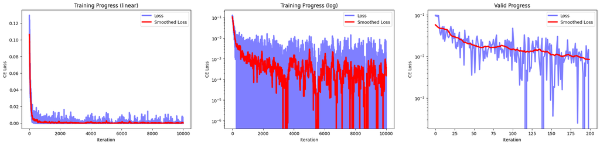

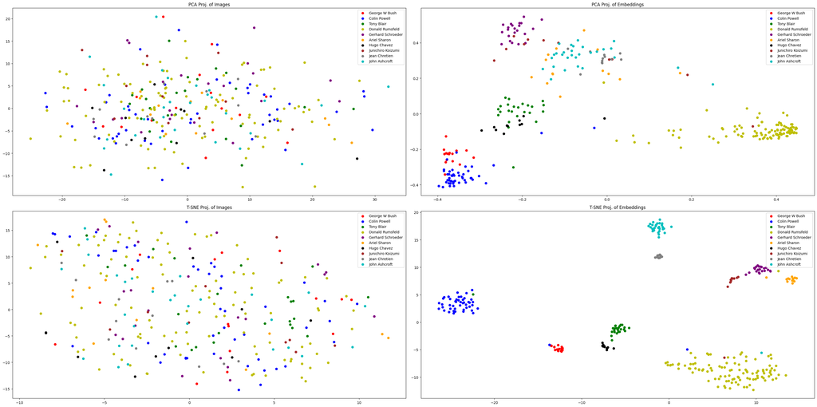

```python
_,_ = utils.plot_all(imgs_flat, embs, labels, labels_mask, legend=legend, stats=stats)
```

```python
utils.calculate_ARI(imgs_flat, embs, labels)
```

```
Clustering images achieves  ARI=2.18%
Clustering embeddings achieves ARI=58.7%
```

### Margin 0.5, Temprature 1.0

```python
model, optimizer, epoch, stats = utils.load_model(trainer.model, trainer.optimizer, savepath="checkpoints/checkpoint_epoch_10000_margin_0.5_temperature_1.0.pth")
```

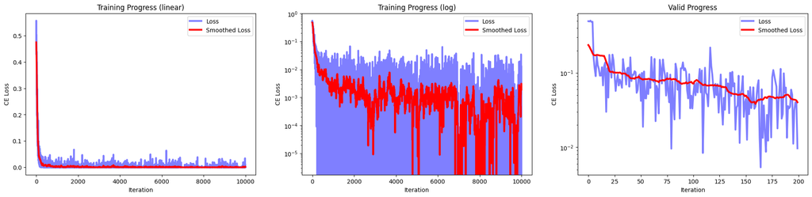

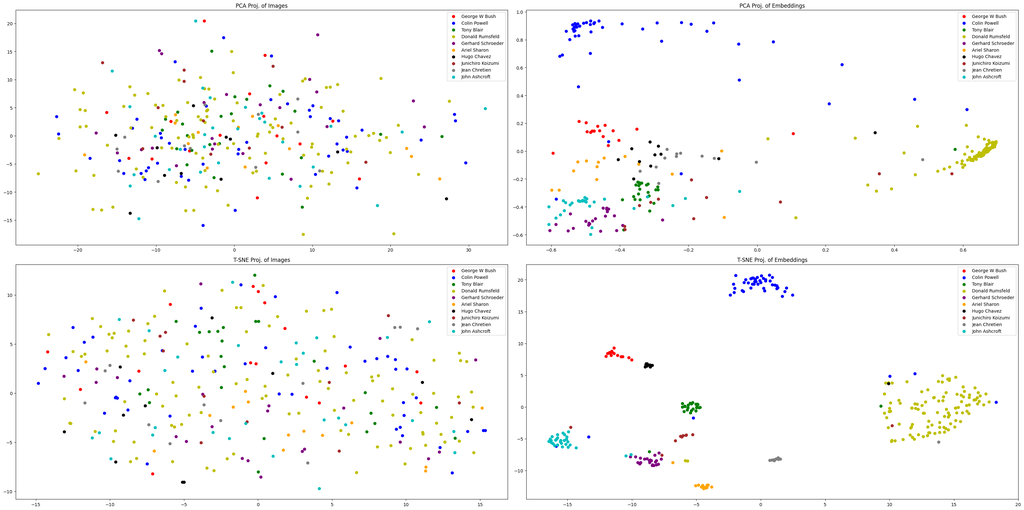

```python
imgs_flat, embs, labels = utils.get_embeddings(model, test_loader, device)

tsne_embs, filtered_indices = utils.plot_all(imgs_flat, embs, labels, labels_mask, legend, stats)
```

```python
utils.calculate_ARI(imgs_flat, embs, labels)
```

```
Clustering images achieves  ARI=2.18%
Clustering embeddings achieves ARI=51.61%
```

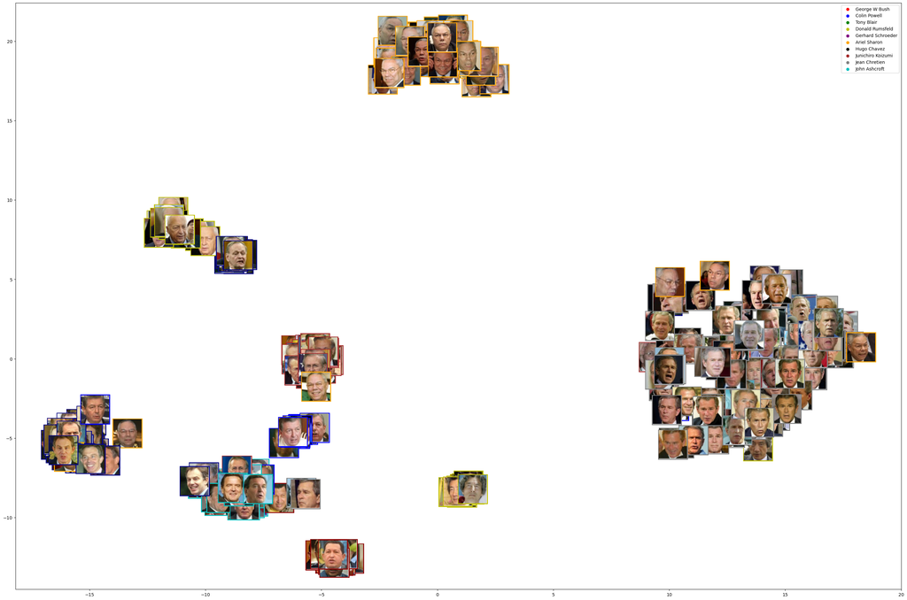

```python
utils.display_projections_images(points=tsne_embs, labels=labels[labels_mask], dataset=test_dataset, legend=legend, indices=filtered_indices)
```

### Margin = 1.0, Temprature 1.0

```python
model, optimizer, epoch, stats = utils.load_model(trainer.model, trainer.optimizer, savepath="checkpoints/checkpoint_epoch_10000_margin_1.0_temperature_1.0.pth")
```

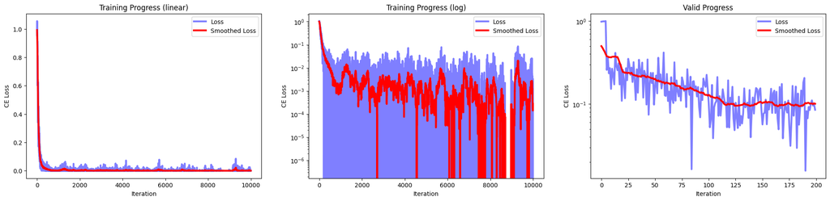

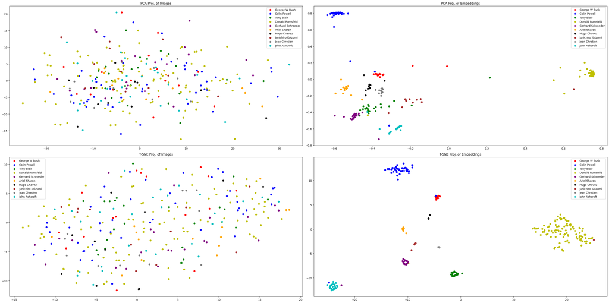

```python
imgs_flat, embs, labels = utils.get_embeddings(model, test_loader, device)
tsne_embs, filtered_indices =utils.plot_all(imgs_flat, embs, labels, labels_mask, legend, stats)
```

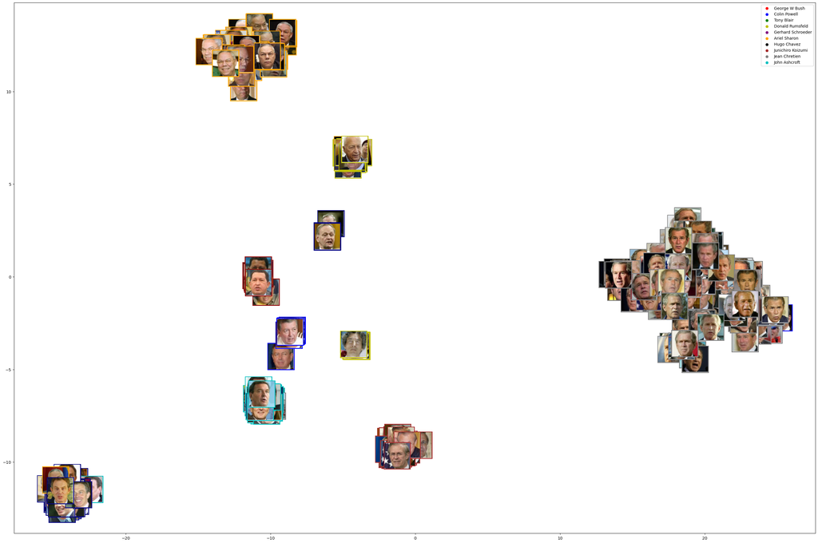

```python
utils.display_projections_images(points=tsne_embs, labels=labels[labels_mask], dataset=test_dataset, legend=legend, indices=filtered_indices)
```

```python
utils.calculate_ARI(imgs_flat, embs, labels)
```

```
Clustering images achieves  ARI=2.18%
Clustering embeddings achieves ARI=63.57%
```

### Margin = 1.0, Temprature 0.5

```python
model, optimizer, epoch, stats = utils.load_model(trainer.model, trainer.optimizer, savepath="checkpoints/checkpoint_epoch_10000_margin_1.0_temperature_0.5.pth")

imgs_flat, embs, labels = utils.get_embeddings(model, test_loader, device)
```

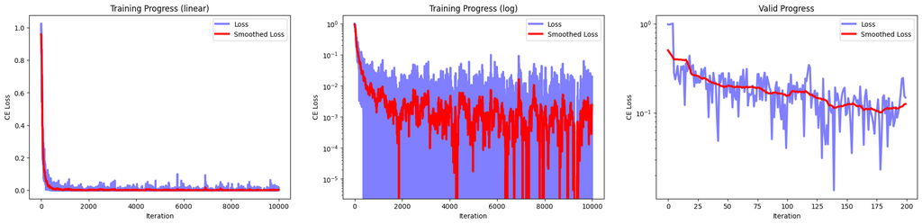

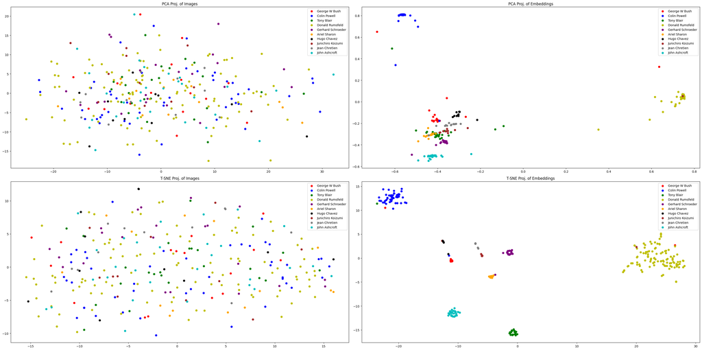

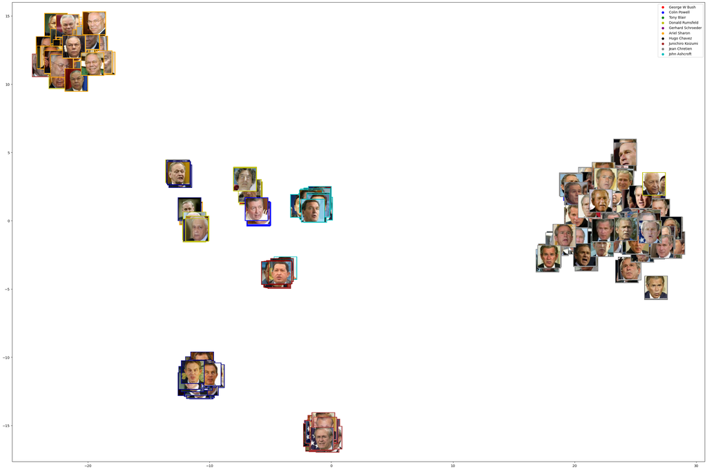

```python
tsne_embs, filtered_indices = utils.plot_all(imgs_flat, embs, labels, labels_mask, legend, stats)
utils.display_projections_images(points=tsne_embs, labels=labels[labels_mask], dataset=test_dataset, legend=legend, indices=filtered_indices)
```

```python
utils.calculate_ARI(imgs_flat, embs, labels)
```

```
Clustering images achieves  ARI=2.18%
Clustering embeddings achieves ARI=58.79%
```

### Margine 1.0, Temprature 0.1

```python
model, optimizer, epoch, stats = utils.load_model(trainer.model, trainer.optimizer, savepath="checkpoints/checkpoint_epoch_10000_margin_1.0_temperature_0.1.pth")
imgs_flat, embs, labels = utils.get_embeddings(model, test_loader, device)
```

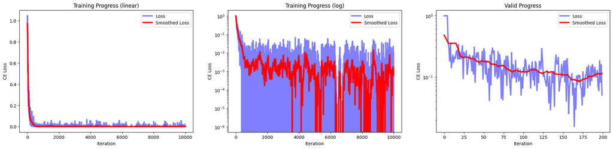

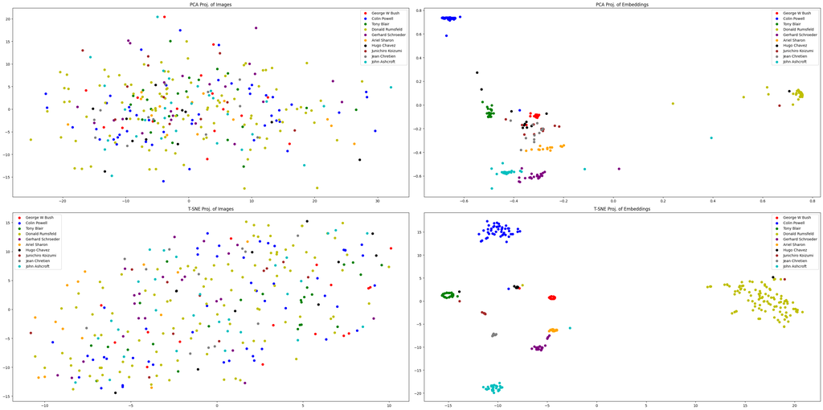

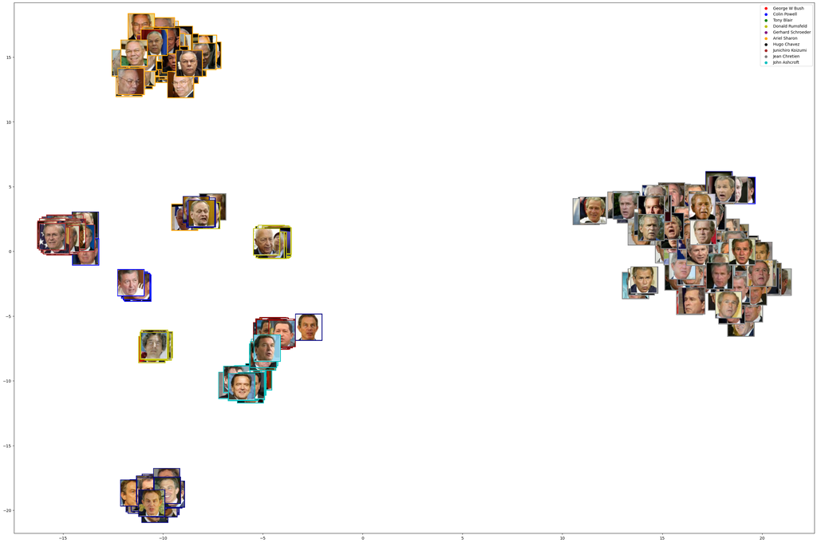

```python
tsne_embs, filtered_indices = utils.plot_all(imgs_flat, embs, labels, labels_mask, legend, stats)
utils.display_projections_images(points=tsne_embs, labels=labels[labels_mask], dataset=test_dataset, legend=legend, indices=filtered_indices)
```

```python
utils.calculate_ARI(imgs_flat, embs, labels)
```

```
Clustering images achieves  ARI=2.18%
Clustering embeddings achieves ARI=59.65%
```

### Training Results Comparison Table

Based on the training results from different temperatures and margins, here's a comparison table:

| Temperature | Margin | ARI Score | Performance |
| --- | --- | --- | --- |
| 1.0 | 0.1 | 58.7 | Fair |
| 1.0 | 0.5 | 51.61 | Poor |
| 1.0 | 1.0 | 63.57 | Best |
| 0.5 | 1.0 | 58.79 | Good |
| 0.1 | 1.0 | 59.65 | Better |

**Key Observations:**

- Higher margins (1.0) tend to improve performance
- Best combination: Temperature=1.0, Margin=1.0
- Worst combination: Temperature=1.0, Margin=0.5

### SimCLR

```python
BATCH_SIZE = 512
simclr_db = utils.SimCLRDataset(dataset=X_train)
data_loader = torch.utils.data.DataLoader(
                                            simclr_db,
                                            batch_size=BATCH_SIZE,
                                            shuffle=True,
                                            num_workers=2
                                        )
```

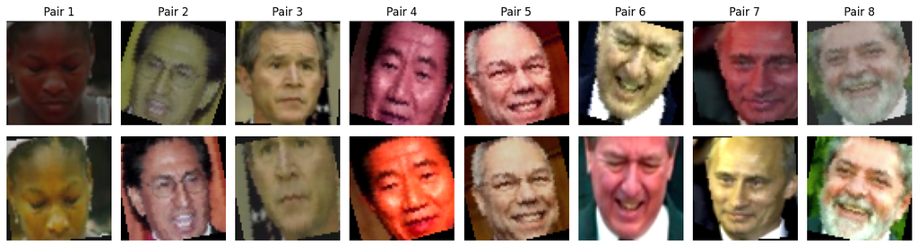

```python
%matplotlib inline
import matplotlib
from matplotlib import pyplot as plt
matplotlib.style.use('default')

fig, ax = plt.subplots(2, 8)
fig.set_size_inches(14, 4)
for i in range(8):
    view1, view2 , _= simclr_db[i]
    view1 = view1.permute(1, 2, 0).numpy()
    view2 = view2.permute(1, 2, 0).numpy()
    ax[0, i].imshow(view1)
    ax[1, i].imshow(view2)
    ax[0, i].axis("off")
    ax[1, i].axis("off")
    ax[0, i].set_title(f"Pair {i+1}")

plt.tight_layout()
plt.show()
```

```python
class SimCLR(nn.Module):
        """
        SimCLR model with ResNet-18 Backbone
        """
        def __init__(self, hidden_dim=512, output_dim=128):
            super().__init__()

            # Use a pre-trained ResNet18 but modify for grayscale input
            self.backbone = models.resnet18(weights=None)
            self.backbone.conv1 = nn.Conv2d(3, 64, kernel_size=7, stride=2, padding=3, bias=False)
            self.backbone.fc = nn.Identity()

            # projection head
            self.proj_head = nn.Sequential(
                    nn.Linear(512, hidden_dim),
                    nn.ReLU(),
                    nn.Linear(hidden_dim, output_dim)
                )
            return

        def forward(self, x):
            h = self.backbone(x)
            z = self.proj_head(h)
            out = F.normalize(z, dim=1)  # L2 normalize
            return out
```

### SimCLR Temprature 0.5

```python
model = SimCLR().to(device)
optimizer = torch.optim.Adam(model.parameters(), lr=1e-3)

test_dataset = utils.SimCLRDataset(X_test, labels=y_test, test=True)
test_loader = torch.utils.data.DataLoader(
        test_dataset,
        batch_size=512,
        shuffle=False,
        num_workers=2
    )
```

```python
model, optimizer, epoch, stats = utils.load_model(model, optimizer, savepath="checkpoints/checkpoint_epoch_300_margin_0_temperature_0.5.pth")
imgs_flat, embs, labels = utils.get_embeddings(model, test_loader, device, simclr=True)
```

```
  warnings.warn(
```

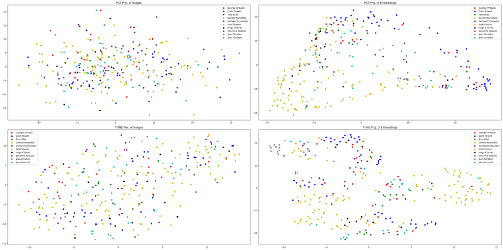

```python
tsne_embs = utils.plot_both(imgs_flat[labels_mask], embs[labels_mask], labels[labels_mask], legend)
```

```python
utils.calculate_ARI(imgs_flat, embs, labels)
```

```
Clustering images achieves  ARI=2.18%
Clustering embeddings achieves ARI=8.98%
```

### SimCLR Temprature 1.0

```python
model, optimizer, epoch, stats = utils.load_model(model, optimizer, savepath="checkpoints/checkpoint_epoch_300_margin_0_temperature_1.0.pth")
imgs_flat, embs, labels = utils.get_embeddings(model, test_loader, device, simclr=True)
```

```
  warnings.warn(
```

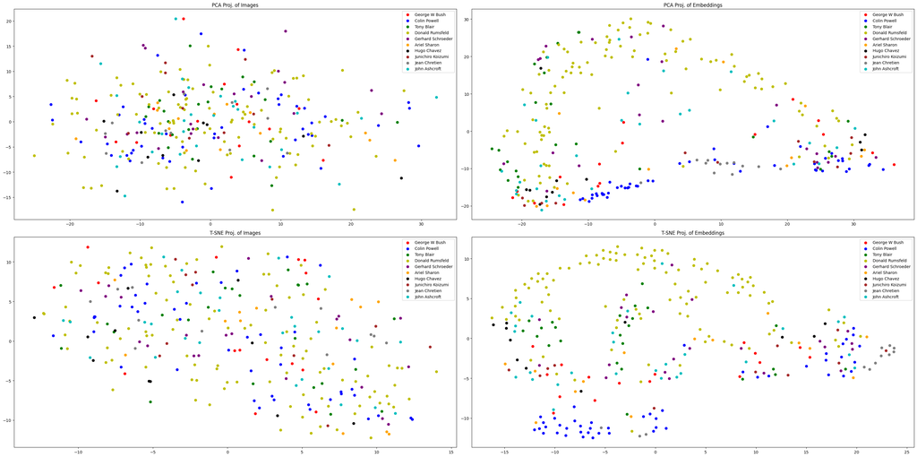

```python
tsne_embs = utils.plot_both(imgs_flat[labels_mask], embs[labels_mask], labels[labels_mask], legend)
```

```python
utils.calculate_ARI(imgs_flat, embs, labels)
```

```
Clustering images achieves  ARI=2.18%
Clustering embeddings achieves ARI=9.26%
```

### Observations

Our SimCLR model performed noticeably worse than the Triplet model. We believe this can be due to the following reasons:

- **SimCLR**:

Trained using a `contrastive loss` that pulls augmented views of the same image together while pushing random image pairs apart.

It doesn’t use explicit label information during training (i.e. `unsupervised` or `self-supervised`).

- **Triplet Network**:

Uses `supervised` metric learning, `trained on triplets` (anchor, positive, negative), making the learning more focused and discriminative.

Optimizes the model to make an anchor closer to a positive (same class) than a negative (different class) by a margin.

Moreover, to train such a large network as resnet from scratch and in an unsupervised manner, we are definitely going to need a large dataset with a lot of training considerations to actually reach a good performance. The poor performance of SimCLR model here is mainly due to the limited amount of data in our dataset.